# Targeting A Housing Subsidy

HanzhiZhang

Nov 3,2022

# Import Data

```r
options(scipen=10000000)

library(tidyverse)
library(kableExtra)
library(caret)
library(knitr)
library(pscl)
library(plotROC)
library(pROC)
library(lubridate)
```

```r
palette5 <- c("#981FAC","#CB0F8B","#FF006A","#FE4C35","#FE9900")
palette4 <- c("#981FAC","#FF006A","#FE4C35","#FE9900")
palette2 <- c("#981FAC","#FF006A")

housecredit <- read.csv('./housingSubsidy.csv') %>%
  mutate(y = as.factor(y))
```

# 1. Motivation

**To decrease the severe situation in housing and economic problem, HCD wants to improve householders’ conditions by offering a home repair tax credit. Data analytics is helpful in this process. As we all know, the low conversion rate of promotion, offer, and allocation credits will lead to low effectiveness of HCD. The department will pay more because they can not reach out the eligible homeowners. I think data science can be helpful in this condition, especially the logic model, which can categorize people’s willingness to take credit.**

# 2. Data Exploration

```r
glimpse(housecredit)
```

```
## Rows: 4,119
## Columns: 22
## $ X                <int> 1, 2, 3, 4, 5, 6, 7, 8, 9, 10, 11, 12, 13, 14, 15, 16…
## $ age              <int> 30, 39, 25, 38, 47, 32, 32, 41, 31, 35, 25, 36, 36, 4…
## $ job              <chr> "blue-collar", "services", "services", "services", "a…
## $ marital          <chr> "married", "single", "married", "married", "married",…
## $ education        <chr> "basic.9y", "high.school", "high.school", "basic.9y",…
## $ taxLien          <chr> "no", "no", "no", "no", "no", "no", "no", "unknown", …
## $ mortgage         <chr> "yes", "no", "yes", "unknown", "yes", "no", "yes", "y…
## $ taxbill_in_phl   <chr> "yes", "yes", "yes", "no", "yes", "yes", "yes", "yes"…
## $ contact          <chr> "cellular", "telephone", "telephone", "telephone", "c…
## $ month            <chr> "may", "may", "jun", "jun", "nov", "sep", "sep", "nov…
## $ day_of_week      <chr> "fri", "fri", "wed", "fri", "mon", "thu", "mon", "mon…
## $ campaign         <int> 2, 4, 1, 3, 1, 3, 4, 2, 1, 1, 1, 1, 2, 2, 2, 2, 6, 4,…
## $ pdays            <int> 999, 999, 999, 999, 999, 999, 999, 999, 999, 999, 999…
## $ previous         <int> 0, 0, 0, 0, 0, 2, 0, 0, 1, 0, 0, 0, 0, 0, 0, 0, 0, 0,…
## $ poutcome         <chr> "nonexistent", "nonexistent", "nonexistent", "nonexis…
## $ unemploy_rate    <dbl> -1.8, 1.1, 1.4, 1.4, -0.1, -1.1, -1.1, -0.1, -0.1, 1.…
## $ cons.price.idx   <dbl> 92.893, 93.994, 94.465, 94.465, 93.200, 94.199, 94.19…
## $ cons.conf.idx    <dbl> -46.2, -36.4, -41.8, -41.8, -42.0, -37.5, -37.5, -42.…
## $ inflation_rate   <dbl> 1.313, 4.855, 4.962, 4.959, 4.191, 0.884, 0.879, 4.19…
## $ spent_on_repairs <dbl> 5099.1, 5191.0, 5228.1, 5228.1, 5195.8, 4963.6, 4963.…
## $ y                <fct> no, no, no, no, no, no, no, no, no, no, no, no, no, n…
## $ y_numeric        <int> 0, 0, 0, 0, 0, 0, 0, 0, 0, 0, 0, 0, 0, 0, 0, 0, 0, 0,…
```

Plots of variables - both continuous and categorical. Examine the relationship between each independent variable and independent variable (Credit or not).

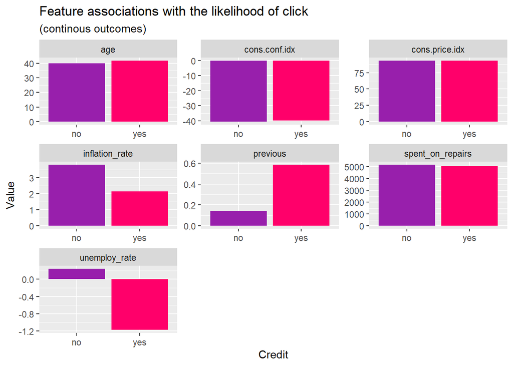

```r
housecredit %>%
  dplyr::select(y,age, previous, unemploy_rate, cons.price.idx, cons.conf.idx, inflation_rate, spent_on_repairs) %>%
  gather(Variable, value, -y) %>%
    ggplot(aes(y, value, fill=y)) +
      geom_bar(position = "dodge", stat = "summary", fun = "mean") +
      facet_wrap(~Variable, scales = "free") +
      scale_fill_manual(values = palette2) +
      labs(x="Credit", y="Value",
           title = "Feature associations with the likelihood of click",
           subtitle = "(continous outcomes)") +
      theme(legend.position = "none")
```

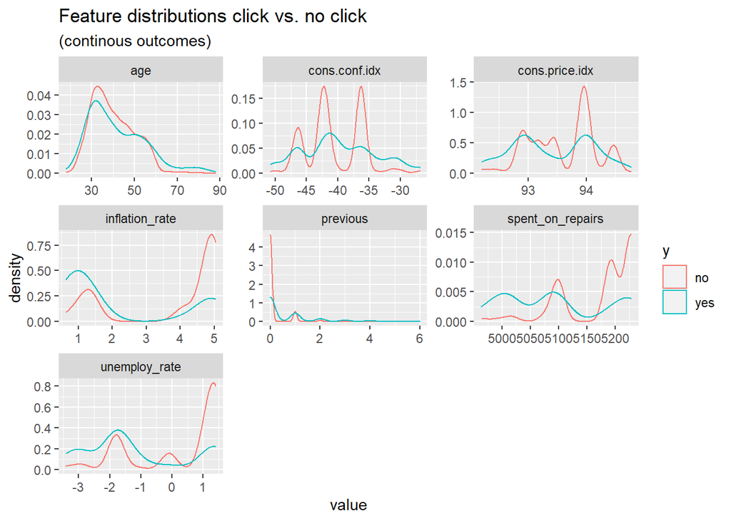

```r
housecredit %>%
    dplyr::select(y,age, previous, unemploy_rate, cons.price.idx, cons.conf.idx, inflation_rate, spent_on_repairs) %>%
    gather(Variable, value, -y) %>%
    ggplot() +
    geom_density(aes(value, color=y), fill = "transparent") +
    facet_wrap(~Variable, scales = "free") +
    scale_fill_manual(values = palette2) +
    labs(title = "Feature distributions click vs. no click",
         subtitle = "(continous outcomes)")
```

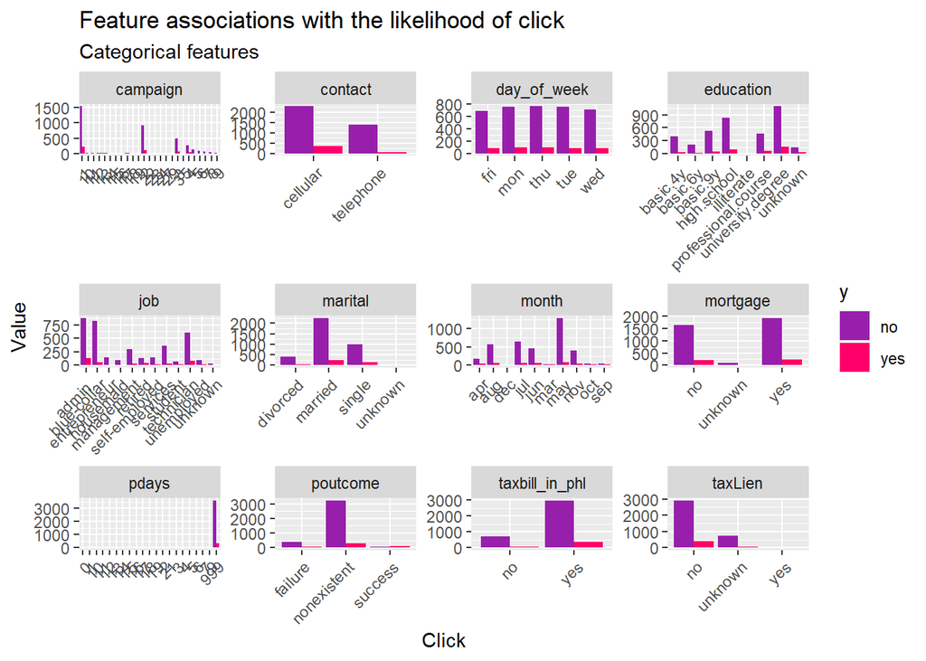

```r
housecredit %>%
    dplyr::select(y, job, marital, education, taxLien, mortgage, taxbill_in_phl, contact, month, day_of_week, campaign, pdays, poutcome) %>%
    gather(Variable, value, -y) %>%
    count(Variable, value, y) %>%
      ggplot(., aes(value, n, fill = y)) +
        geom_bar(position = "dodge", stat="identity") +
        facet_wrap(~Variable, scales="free") +
        scale_fill_manual(values = palette2) +
        labs(x="Click", y="Value",
             title = "Feature associations with the likelihood of click",
             subtitle = "Categorical features") +
        theme(axis.text.x = element_text(angle = 45, hjust = 1))
```

```r
unique(housecredit$job)
```

```
##  [1] "blue-collar"   "services"      "admin."        "entrepreneur"
##  [5] "self-employed" "technician"    "management"    "student"
##  [9] "retired"       "housemaid"     "unemployed"    "unknown"
```

```r
housecredit <-
  housecredit %>%
  mutate(generation = cut(age, breaks = 3, labels = c("Low","Medium","High"))) %>%
  mutate(previousno = as.factor(case_when(previous < 1  ~ "NO", previous > 0  ~ "YES"))) %>%
  mutate(highincome = case_when(job == "admin." | job == "entrepreneur"| job == "management" ~ "YES", TRUE ~ "NO"))
```

# 3. Split Data and Make Predictions

```r
set.seed(3456)
trainIndex <- createDataPartition(
  y = paste(housecredit$contact,housecredit$month,housecredit$day_of_week,housecredit$campaign,housecredit$poutcome), p = .65,
                                  list = FALSE,
                                  times = 1)
Train <- housecredit[ trainIndex,]
Test  <- housecredit[-trainIndex,]
```

# 4. Engineer new features and Create two Logistic Regression Model (before and after feature engineering)

## a. Feature Engineering

Create 3 variables: generation, previouson, highincome. Considering age is a big range, I try to use category variables to translate the continues age. According to to divide the data into 3 levels of age, I assign them “low”,“medium”,“high” age generation. I noticed there is no variable distinguishing whether householders were contacted before, so I add a variable called “previousno”, which means people were not contacted in the previous campaign. The last variable is highincome. I sort the people’s job is administor, entrepreneur, and management. Try to find out if high-income people will not accept the credit.

But after modeling, seems all of them perform badly in the model. So I removed them to achieve model accuracy.

```r
Model1 <- glm(Train$y_numeric ~ .,
              data=Train %>% dplyr::select(-previous, -y_numeric, -y, -job, -generation, -previousno, -highincome),
              family="binomial" (link="logit"))

summary(Model1)
```

```
##
## Call:
## glm(formula = Train$y_numeric ~ ., family = binomial(link = "logit"),
##     data = Train %>% dplyr::select(-previous, -y_numeric, -y,
##         -job, -generation, -previousno, -highincome))
##
## Deviance Residuals:
##     Min       1Q   Median       3Q      Max
## -1.9837  -0.3951  -0.3227  -0.2536   2.9192
##
## Coefficients:
##                                   Estimate    Std. Error z value Pr(>|z|)
## (Intercept)                  -144.07510016  120.65605123  -1.194 0.232440
## X                              -0.00003224    0.00005530  -0.583 0.559860
## age                             0.01216444    0.00658945   1.846 0.064885 .
## maritalmarried                 -0.01424093    0.22013647  -0.065 0.948420
## maritalsingle                   0.15135478    0.25323998   0.598 0.550058
## maritalunknown                -11.31769013  385.71233779  -0.029 0.976592
## educationbasic.6y               0.32651714    0.38721110   0.843 0.399087
## educationbasic.9y               0.07544480    0.31410269   0.240 0.810182
## educationhigh.school            0.21640920    0.27983570   0.773 0.439319
## educationilliterate           -13.10699722  882.74348806  -0.015 0.988153
## educationprofessional.course    0.26359648    0.30185503   0.873 0.382524
## educationuniversity.degree      0.25668910    0.27118477   0.947 0.343870
## educationunknown                0.32318937    0.37011736   0.873 0.382550
## taxLienunknown                  0.05558468    0.20596475   0.270 0.787257
## taxLienyes                    -11.10247993  882.74345250  -0.013 0.989965
## mortgageunknown                -0.05622441    0.48878352  -0.115 0.908422
## mortgageyes                    -0.05729702    0.13417864  -0.427 0.669364
## taxbill_in_phlyes               0.12973524    0.18466726   0.703 0.482345
## contacttelephone               -0.94179154    0.25510053  -3.692 0.000223 ***
## monthaug                        0.11254061    0.39755895   0.283 0.777116
## monthdec                        0.83112695    0.60551271   1.373 0.169877
## monthjul                       -0.04266162    0.34379106  -0.124 0.901243
## monthjun                        0.09857622    0.41538298   0.237 0.812413
## monthmar                        1.75308972    0.49649182   3.531 0.000414 ***
## monthmay                       -0.28231887    0.28378573  -0.995 0.319818
## monthnov                       -0.43704272    0.39975804  -1.093 0.274276
## monthoct                       -0.24170967    0.50436099  -0.479 0.631768
## monthsep                       -0.24768418    0.57440081  -0.431 0.666320
```

[output cut: 8 more lines]

```
## unemploy_rate                  -0.91264586    0.44373808  -2.057 0.039713 *
## cons.price.idx                  1.45447025    0.79280958   1.835 0.066568 .
## cons.conf.idx                   0.04325675    0.02575027   1.680 0.092985 .
## inflation_rate                  0.06407308    0.41241948   0.155 0.876538
## spent_on_repairs                0.00135515    0.00980632   0.138 0.890089
## ---
## Signif. codes:  0 '***' 0.001 '**' 0.01 '*' 0.05 '.' 0.1 ' ' 1
##
## (Dispersion parameter for binomial family taken to be 1)
##
##     Null deviance: 2179.0  on 2973  degrees of freedom
## Residual deviance: 1659.2  on 2933  degrees of freedom
## AIC: 1741.2
##
## Number of Fisher Scoring iterations: 13
```

```r
Model2 <- glm(Train$y_numeric ~ .,
              data=Train %>% dplyr::select(contact, month, campaign, poutcome, unemploy_rate, age, cons.price.idx, cons.conf.idx ),
              family="binomial" (link="logit"))

summary(Model2)
```

```
##
## Call:
## glm(formula = Train$y_numeric ~ ., family = binomial(link = "logit"),
##     data = Train %>% dplyr::select(contact, month, campaign,
##         poutcome, unemploy_rate, age, cons.price.idx, cons.conf.idx))
##
## Deviance Residuals:
##     Min       1Q   Median       3Q      Max
## -1.9397  -0.3916  -0.3307  -0.2570   2.8225
##
## Coefficients:
##                        Estimate  Std. Error z value             Pr(>|z|)
## (Intercept)         -122.883101   15.919416  -7.719   0.0000000000000117 ***
## contacttelephone      -0.933042    0.231962  -4.022   0.0000576096943779 ***
## monthaug               0.111604    0.346040   0.323              0.74706
## monthdec               0.818565    0.549077   1.491              0.13601
## monthjul              -0.010613    0.332559  -0.032              0.97454
## monthjun               0.206302    0.300190   0.687              0.49193
## monthmar               1.713977    0.401711   4.267   0.0000198396262954 ***
## monthmay              -0.302900    0.259771  -1.166              0.24360
## monthnov              -0.395554    0.319113  -1.240              0.21514
## monthoct              -0.230271    0.402622  -0.572              0.56737
## monthsep              -0.277950    0.414780  -0.670              0.50278
## campaign              -0.102865    0.039156  -2.627              0.00861 **
## poutcomenonexistent    0.400898    0.191260   2.096              0.03607 *
## poutcomesuccess        1.706161    0.263733   6.469   0.0000000000984742 ***
## unemploy_rate         -0.757648    0.071470 -10.601 < 0.0000000000000002 ***
## age                    0.007536    0.005353   1.408              0.15921
## cons.price.idx         1.305796    0.172666   7.563   0.0000000000000395 ***
## cons.conf.idx          0.044034    0.016908   2.604              0.00920 **
## ---
## Signif. codes:  0 '***' 0.001 '**' 0.01 '*' 0.05 '.' 0.1 ' ' 1
##
## (Dispersion parameter for binomial family taken to be 1)
##
##     Null deviance: 2179.0  on 2973  degrees of freedom
## Residual deviance: 1665.4  on 2956  degrees of freedom
## AIC: 1701.4
##
## Number of Fisher Scoring iterations: 6
```

## b.Regression Summary

Model before feature engineering’s McFadden higher than later one. Maybe the feature engineering failed to improve the model.

```r
pR2(Model1)
```

```
## fitting null model for pseudo-r2
```

```
##           llh       llhNull            G2      McFadden          r2ML
##  -829.5958567 -1089.4803517   519.7689900     0.2385399     0.1603507
##          r2CU
##     0.3087373
```

```r
pR2(Model2)
```

```
## fitting null model for pseudo-r2
```

```
##           llh       llhNull            G2      McFadden          r2ML
##  -832.7053231 -1089.4803517   513.5500572     0.2356858     0.1585931
##          r2CU
##     0.3053532
```

## c.Cross validation

Run 100-fold cross validation and look at the ROC (aka AUC), Sensitivity and Specificity across this series of predicitons.

```r
ctrl <- trainControl(method = "cv", number = 100, classProbs=TRUE, summaryFunction=twoClassSummary)

beforecvFit <- train(y ~ ., data = housecredit %>%
                                        dplyr::select(-previous, -y_numeric, -job),
                method="glm", family="binomial",
                metric="ROC", trControl = ctrl)

beforecvFit
```

```
## Generalized Linear Model
##
## 4119 samples
##   21 predictor
##    2 classes: 'no', 'yes'
##
## No pre-processing
## Resampling: Cross-Validated (100 fold)
## Summary of sample sizes: 4077, 4078, 4078, 4078, 4078, 4078, ...
## Resampling results:
##
##   ROC        Sens       Spec
##   0.7696351  0.9830781  0.2265
```

```r
cvFit <- train(y ~ ., data = housecredit %>%
                              dplyr::select(y, contact, month, campaign, poutcome, unemploy_rate, age, cons.price.idx, cons.conf.idx),
                method="glm", family="binomial",
                metric="ROC", trControl = ctrl)

cvFit
```

```
## Generalized Linear Model
##
## 4119 samples
##    8 predictor
##    2 classes: 'no', 'yes'
##
## No pre-processing
## Resampling: Cross-Validated (100 fold)
## Summary of sample sizes: 4078, 4079, 4077, 4079, 4077, 4079, ...
## Resampling results:
##
##   ROC       Sens       Spec
##   0.783525  0.9860886  0.2285
```

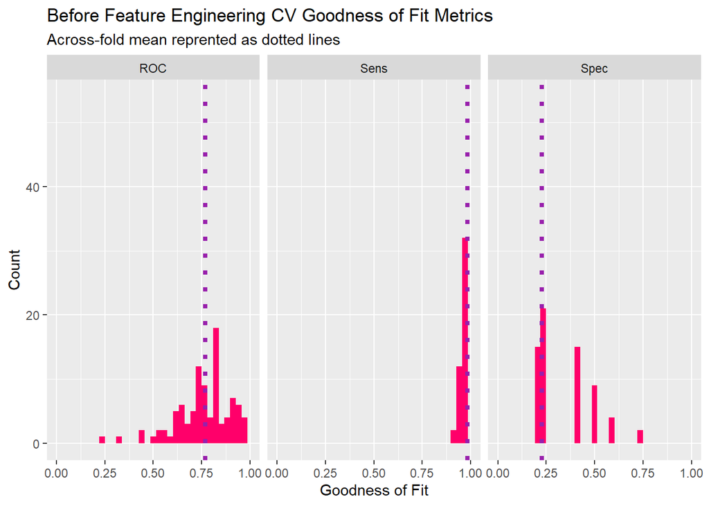

```r
dplyr::select(beforecvFit$resample, -Resample) %>%
  gather(metric, value) %>%
  left_join(gather(beforecvFit$results[2:4], metric, mean)) %>%
  ggplot(aes(value)) +
    geom_histogram(bins=35, fill = "#FF006A") +
    facet_wrap(~metric) +
    geom_vline(aes(xintercept = mean), colour = "#981FAC", linetype = 3, size = 1.5) +
    scale_x_continuous(limits = c(0, 1)) +
    labs(x="Goodness of Fit", y="Count", title="Before Feature Engineering CV Goodness of Fit Metrics",
         subtitle = "Across-fold mean reprented as dotted lines")
```

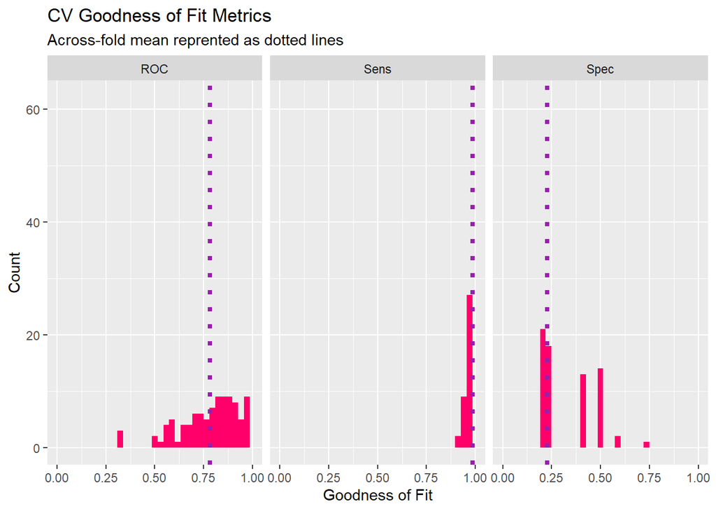

```r
dplyr::select(cvFit$resample, -Resample) %>%
  gather(metric, value) %>%
  left_join(gather(cvFit$results[2:4], metric, mean)) %>%
  ggplot(aes(value)) +
    geom_histogram(bins=35, fill = "#FF006A") +
    facet_wrap(~metric) +
    geom_vline(aes(xintercept = mean), colour = "#981FAC", linetype = 3, size = 1.5) +
    scale_x_continuous(limits = c(0, 1)) +
    labs(x="Goodness of Fit", y="Count", title="CV Goodness of Fit Metrics",
         subtitle = "Across-fold mean reprented as dotted lines")
```

These predictions are the estimated probabilities of clicking for these out-of-sample subjects. We can compare them to the observed outcome.

Run the code below and explore using `glimpse(testProbs)` to see what these predictions look like.

```r
testProbs <- data.frame(Outcome = as.factor(Test$y_numeric),
                        Probs = predict(Model2, Test, type= "response"))
```

The model performs well in people who don’t get the credit. But the people who will get the credit curve is flatten and has a small peak in the low threshold.

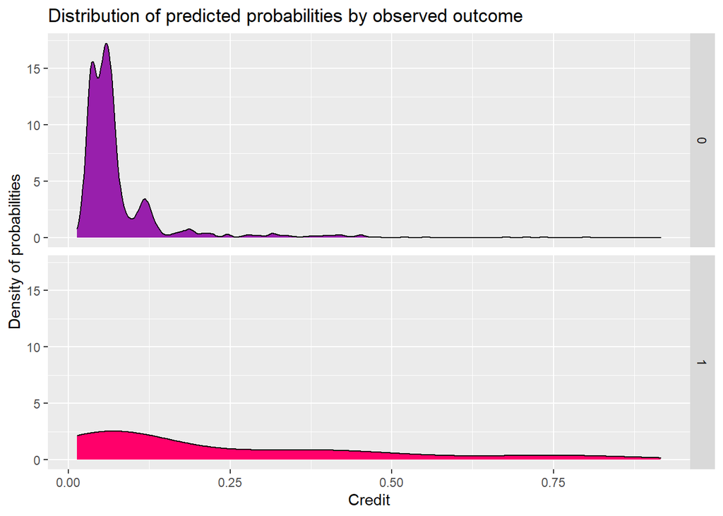

```r
ggplot(testProbs, aes(x = Probs, fill = as.factor(Outcome))) +
  geom_density() +
  facet_grid(Outcome ~ .) +
  scale_fill_manual(values = palette2) +
  labs(x = "Credit", y = "Density of probabilities",
       title = "Distribution of predicted probabilities by observed outcome") +
  theme(strip.text.x = element_text(size = 18),
        legend.position = "none")
```

A confusion matrix for the threshold of 50% shows the rate at which we got True Positives, False Positives, True Negatives and False Negatives for that threshold.

```r
testProbs <-
  testProbs %>%
  mutate(predOutcome  = as.factor(ifelse(testProbs$Probs > 0.5 , 1, 0)))
```

```r
caret::confusionMatrix(testProbs$predOutcome, testProbs$Outcome,
                       positive = "1")
```

```
## Confusion Matrix and Statistics
##
##           Reference
## Prediction    0    1
##          0 1044   81
##          1    6   14
##
##                Accuracy : 0.924
##                  95% CI : (0.9071, 0.9387)
##     No Information Rate : 0.917
##     P-Value [Acc > NIR] : 0.2123
##
##                   Kappa : 0.221
##
##  Mcnemar's Test P-Value : 0.000000000000002128
##
##             Sensitivity : 0.14737
##             Specificity : 0.99429
##          Pos Pred Value : 0.70000
##          Neg Pred Value : 0.92800
##              Prevalence : 0.08297
##          Detection Rate : 0.01223
##    Detection Prevalence : 0.01747
##       Balanced Accuracy : 0.57083
##
##        'Positive' Class : 1
##
```

# 5. ROC Curve

The area under the curve is 0.7072, which is a medium value of AOC. The y-axis of the ROC curve shows the rate of true positives for each threshold from 0.01 to 1. The x-axis shows the rate of false positives for each threshold. This ROC curve below shows the model has a better appearance in a low threshold than high threshold. When the true positive increase in the map, the false positive errors will increase, too.

```r
auc(testProbs$Outcome, testProbs$Probs)
```

```
## Area under the curve: 0.7072
```

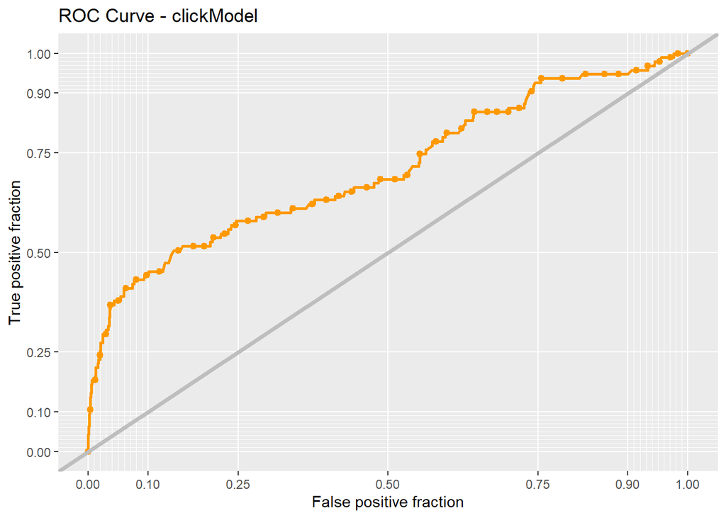

```r
ggplot(testProbs, aes(d = as.numeric(Outcome), m = Probs)) +
  geom_roc(n.cuts = 50, labels = FALSE, colour = "#FE9900") +
  style_roc(theme = theme_grey) +
  geom_abline(slope = 1, intercept = 0, size = 1.5, color = 'grey') +
  labs(title = "ROC Curve - clickModel")
```

# 6. Cost Benefit Analysis

This has all been building to an examination of the model in the context of our ad campaign. Let’s set this up to estimate the revenues associated with using this model under the following scenario:

### a. Cost/Benefit Equation for Confusion Metric

True Positive - Predicted correctly homeowner would enter credit program; allocated the marketing resources, and 25% ultimately achieved the credit. True Negative - Predicted correctly homeowner would not take the credit, no marketing resources were allocated, and no credit was allocated. False Positive - Predicted incorrectly homeowner would take the credit; allocated marketing resources; no credit allocated. False Negative - We predicted that a homeowner would not take the credit but they did. These are likely homeowners who signed up for reasons unrelated to the marketing campaign. Thus, we ‘0 out’ this category, assuming the cost/benefit of this is $0.

### b. Cost/Benefit Table

```r
cost_benefit_table <-
   testProbs %>%
      count(predOutcome, Outcome) %>%
      summarize(True_Negative = sum(n[predOutcome==0 & Outcome==0]),
                True_Positive = sum(n[predOutcome==1 & Outcome==1]),
                False_Negative = sum(n[predOutcome==0 & Outcome==1]),
                False_Positive = sum(n[predOutcome==1 & Outcome==0])) %>%
       gather(Variable, Count) %>%
       mutate(Revenue =
               ifelse(Variable == "True_Negative", (Count*0),
               ifelse(Variable == "True_Positive",(Count * ((-2850-5000+10000+56000)*.25)),
               ifelse(Variable == "False_Negative", 0 * Count,
               ifelse(Variable == "False_Positive", (-2850) * Count, 0))))) %>%
    bind_cols(data.frame(Description = c(
              "Predicted correctly homeowner would not take the credit",
              "Predicted correctly homeowner would enter credit program",
              "Predicted incorrectly homeowner would not take the credit but they did",
              "Predicted incorrectly homeowner would take the credit")))

kable(cost_benefit_table,
       caption = "Cost/Benefit Table") %>% kable_styling()
```

Cost/Benefit Table

| Variable | Count | Revenue | Description |
| --- | --- | --- | --- |
| True_Negative | 1044 | 0 | Predicted correctly homeowner would not take the credit |
| True_Positive | 14 | 203525 | Predicted correctly homeowner would enter credit program |
| False_Negative | 81 | 0 | Predicted incorrectly homeowner would not take the credit but they did |
| False_Positive | 6 | -17100 | Predicted incorrectly homeowner would take the credit |

### c. Plot Confusion Metric Outcomes of Each Threshold

```r
iterateThresholds <- function(data) {
  x = .01
  all_prediction <- data.frame()
  while (x <= 1) {

  this_prediction <-
      testProbs %>%
      mutate(predOutcome = ifelse(Probs > x, 1, 0)) %>%
      count(predOutcome, Outcome) %>%
      summarize(True_Negative = sum(n[predOutcome==0 & Outcome==0]),
                True_Positive = sum(n[predOutcome==1 & Outcome==1]),
                False_Negative = sum(n[predOutcome==0 & Outcome==1]),
                False_Positive = sum(n[predOutcome==1 & Outcome==0])) %>%
     gather(Variable, Count) %>%
     mutate(Revenue =
               ifelse(Variable == "True_Negative", (Count*0),
               ifelse(Variable == "True_Positive",(Count * ((-2850-5000+10000+56000)*.25)),
               ifelse(Variable == "False_Negative", 0 * Count,
               ifelse(Variable == "False_Positive", (-2850) * Count, 0)))),
            Threshold = x)

  all_prediction <- rbind(all_prediction, this_prediction)
  x <- x + .01
  }
return(all_prediction)
}
```

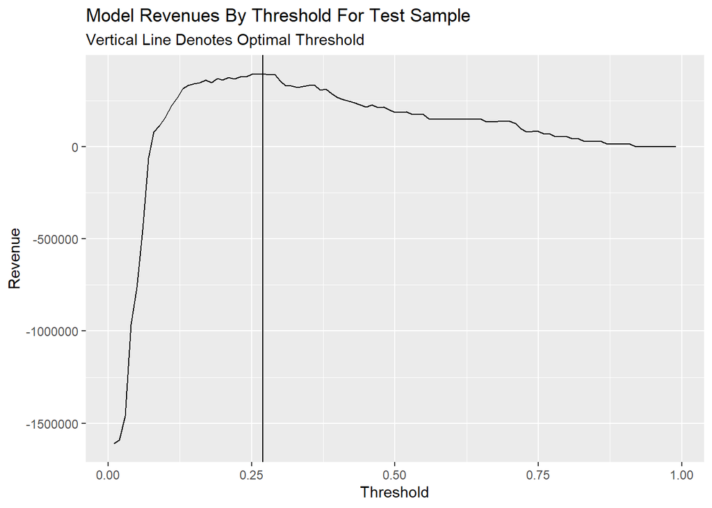

```r
whichThreshold <- iterateThresholds(testProbs2)

whichThreshold_revenue <-
whichThreshold %>%
    group_by(Threshold) %>%
    summarize(Revenue = sum(Revenue))

  ggplot(whichThreshold_revenue)+
  geom_line(aes(x = Threshold, y = Revenue))+
  geom_vline(xintercept =  pull(arrange(whichThreshold_revenue, -Revenue)[1,1]))+
    labs(title = "Model Revenues By Threshold For Test Sample",
         subtitle = "Vertical Line Denotes Optimal Threshold")
```

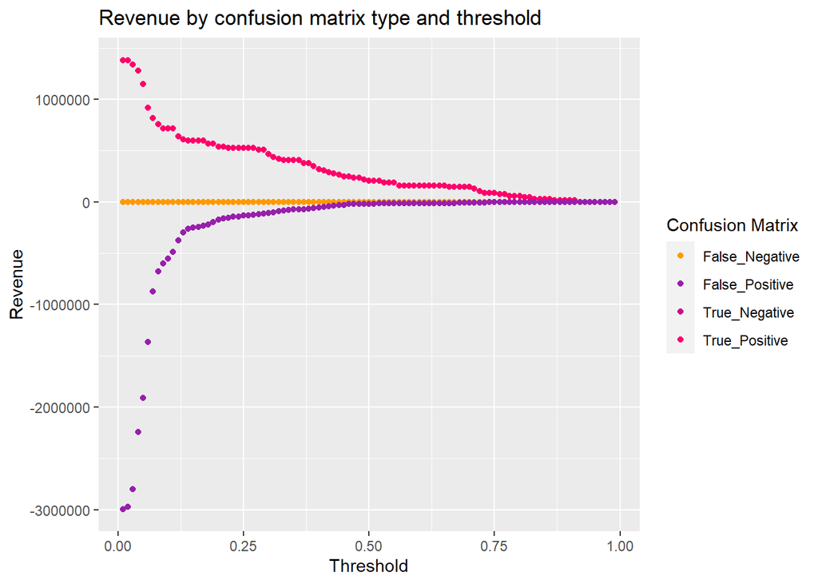

```r
whichThreshold %>%
  ggplot(.,aes(Threshold, Revenue, colour = Variable)) +
  geom_point() +
  scale_colour_manual(values = palette5[c(5, 1:3)]) +
  labs(title = "Revenue by confusion matrix type and threshold",
       y = "Revenue") +
  guides(colour=guide_legend(title = "Confusion Matrix"))
```

The plot of the Threshold as a function of Total_Revenue elaborates that total avenue all converge on 0 when the threshold gets bigger. According to my calculate function of revenue, True_Negative and False_Negative make 0 effects on revenue, so they are stable whether how the threshold change. As for True_Positive, when the threshold gets bigger to 1, the count of True_Positive will decrease close to 0, so the revenue will close to 0. The same as False_Positive.

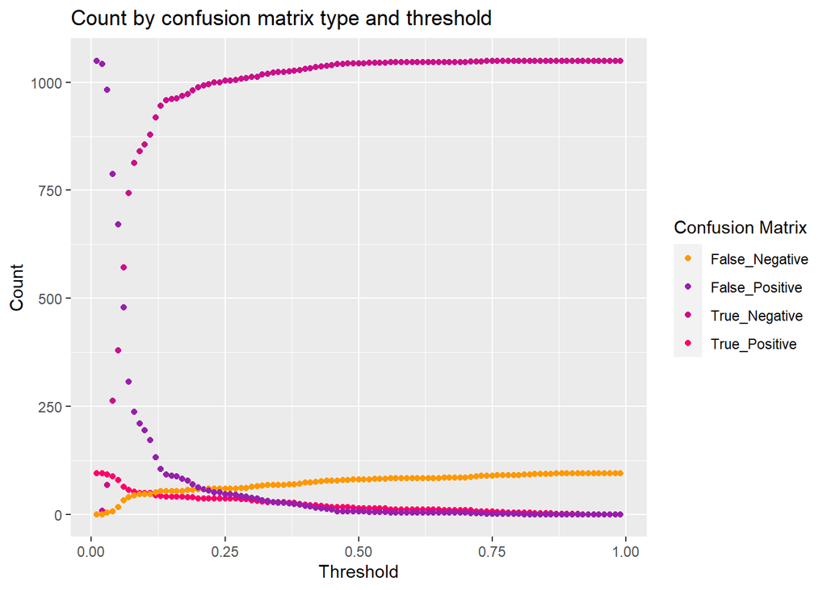

```r
whichThreshold %>%
  ggplot(.,aes(Threshold, Count, colour = Variable)) +
  geom_point() +
  scale_colour_manual(values = palette5[c(5, 1:3)]) +
  labs(title = "Count by confusion matrix type and threshold",
       y = "Count") +
  guides(colour=guide_legend(title = "Confusion Matrix"))
```

The number of each of the negative and positive samples is fixed, this is why the count line of False_Negative & True_Positive, True_Negative & False_Positive are symmetry. This plot can be concluded the total count of negative samples is much bigger than positive samples, which may affect the accuracy difference between negative and positive samples. And both negative and positive results will change a lot in the range of 0.05-0.2 threshold.

```r
compareThreshold<-
  subset(whichThreshold, Threshold == "0.5" | Threshold == "0.26")
compareThreshold2<-
  compareThreshold %>%
    mutate(creditcount = ifelse(Variable == "True_Negative",0,ifelse(Variable == "False_Positive",0,Count)))%>%
    group_by(Threshold)%>%
    summarise(Total_Revenue = sum(Revenue),
              Total_Count_of_Credits = sum(creditcount))
knitr::kable(compareThreshold2, align = "lccrr")
```

| Threshold | Total_Revenue | Total_Count_of_Credits |
| --- | --- | --- |
| 0.26 | 392250 | 95 |
| 0.50 | 186425 | 95 |

I calculate total count of credits by adding the count of True_Positive and False_Negative, which is all the people accepting credits, which is fixed in two thresholds, the same as the plot map. And when model chooses the optimal threshold, the total revenue is 392250, which is much bigger than the revenue of regular threshold.

# 7. Conclusion

**I will not recommand my model.** There are servel reasons:

Personally, I think the reason why the model performs not good is following: 1. Feature: I didn’t find out the better-related variables. 2. Original dataset has less positive data, which can not train model very well.

Potential Problem: When I calculate the revenue of the true positive result, I conclude the influence on the neighborhood, which does not take into sample point overlap problem. If two sample points live near, their total revenue of them will be lower than the sum of revenues of each of them. So I don’t think the outcome of the threshold is robust.